# mass_polr_wecare_nfe

started: Alexey Larionov, 27Feb2017  
last updated: Alexey Larionov, 20Sep2019

# Summary

No statistically significant genes after multiple testing correction  
Top non-significant gene is BRIP1

Reads and checks data.  
Data are already imputed, weighted and aggregated per gene (there was no need in inverting genotypes).

Performs trend test for NFE < UBC < CBC using polr function from MASS library  
Writes results into a text file, then explores this file.

This is a trend test within regression framework using proportional odds regression model.  
Thus, it allows the covariates, which are only eigenvectors in this case.

Polr or multinomial-lr were advised by David Conti (e-mail of 18Nov2016).  
Initially, I tested both. Then I excluded multinomuial because it was messy and,  
in general, multinomial is less sensitive/suitable for ordered categories.

## Input & output data:

- 162 variants (62 genes) x 664 samples (467BC = 232UBC + 235CBC and 197NFE)

# start_section

```r
# Time stamp
Sys.time()
```

```
## [1] "2019-09-20 15:30:11 BST"
```

```r
# Clenan-up
rm(list=ls())
graphics.off()

# Base folder
library(knitr)
base_folder="/Users/alexey/Documents/wecare/ampliseq/v04_ampliseq_nfe/s17_polr"
opts_knit$set(root.dir = base_folder)
#setwd(base_folder)

# Libraries
library(MASS) # for proportional odds regression (polr)
library(dplyr)
library(QQperm)
# Accessory functions
source(paste(base_folder, "f01_tryCatchAdv.R", sep="/"))
source(paste(base_folder, "f02_qqunif_plot.R", sep="/"))
```

# load_data

```r
load(paste(base_folder, "s01_impute_weight_aggregate.RData", sep="/"))
```

# check_data

```r
ls()
```

```
## [1] "base_folder"         "genes_data.mx"       "genes_info.df"       "genotypes_imp_wt.mx" "genotypes.mx"        "phenotypes.df"       "qqunif.plot"         "tryCatchAdv"         "variants.df"
```

```r
dim(genotypes.mx)
```

```
## [1] 162 664
```

```r
dim(genotypes_imp_wt.mx)
```

```
## [1] 162 664
```

```r
dim(genes_data.mx)
```

```
## [1]  62 664
```

```r
dim(genes_info.df)
```

```
## [1] 62 25
```

```r
dim(variants.df)
```

```
## [1] 162  88
```

```r
dim(phenotypes.df)
```

```
## [1] 664  31
```

```r
# Check consistency of rownames and colnames
sum(colnames(genotypes.mx) != rownames(phenotypes.df))
```

```
## [1] 0
```

```r
sum(colnames(genes_data.mx) != rownames(phenotypes.df))
```

```
## [1] 0
```

```r
sum(rownames(genes_info.df) != rownames(genes_data.mx))
```

```
## [1] 0
```

```r
sum(rownames(genotypes.mx) != rownames(genotypes_imp_wt.mx))
```

```
## [1] 0
```

```r
sum(rownames(genotypes.mx) != rownames(variants.df))
```

```
## [1] 0
```

# prepare_data_for_analysis

```r
# Eigenvectors
E <- as.matrix(phenotypes.df[,c("PC1", "PC2")])
E[1:5,]
```

```
##                      PC1         PC2
## 100_S8_L007   -0.0247118  0.00577574
## 101_S528_L008 -0.0154747 -0.00145424
## 102_S466_L008  0.0169168  0.07628740
## 104_S325_L008  0.0129566 -0.02575130
## 105_S337_L008 -0.0035446  0.00500159
```

```r
sum(is.na(E)) # 0
```

```
## [1] 0
```

```r
# Outcomes
table(phenotypes.df$group)
```

```
##
## UBC CBC NFE
## 232 235 197
```

```r
table(phenotypes.df$cc)
```

```
##
##  -1   0   1
## 197 232 235
```

```r
Y <- phenotypes.df$cc + 2 # shift [-1,0,1] to [1,2,3] - natural numbers may better fit to ordered factors later
table(Y)
```

```
## Y
##   1   2   3
## 197 232 235
```

```r
Y <- ordered(Y, levels=c(1,2,3), labels=c("nfe", "ubc", "cbc")) # convert to ordered factor
names(Y) <- as.vector(phenotypes.df$sample_id) # add names (just in case)
str(Y)
```

```
##  Ord.factor w/ 3 levels "nfe"<"ubc"<"cbc": 2 2 2 3 2 2 2 3 3 3 ...
##  - attr(*, "names")= chr [1:664] "100" "101" "102" "104" ...
```

```r
table(Y)
```

```
## Y
## nfe ubc cbc
## 197 232 235
```

```r
Y[c(1,300,500)]
```

```
##     100     430 HG00250
##     ubc     cbc     nfe
## Levels: nfe < ubc < cbc
```

```r
sum(is.na(Y)) # 0
```

```
## [1] 0
```

```r
Y[1:5]
```

```
## 100 101 102 104 105
## ubc ubc ubc cbc ubc
## Levels: nfe < ubc < cbc
```

```r
# Genes
genes <- genes_info.df$gene
length(genes) # 62
```

```
## [1] 62
```

```r
genes[1:5]
```

```
## [1] "EPHB2"   "SZT2"    "C8A"     "DCLRE1B" "MSH2"
```

```r
sum(is.na(genes)) # 0
```

```
## [1] 0
```

```r
# Null model: generated witout error or warning
try.polr.null <- tryCatchAdv(polr(Y ~ E))
try.polr.null$status # "succeeded"
```

```
## [1] "succeeded"
```

```r
# The result is saved in try.polr.null$value

# Check that ther is no missed data
sum(is.na(genes_data.mx)) # 0
```

```
## [1] 0
```

# polr

Loop through each gene, perform polr analyses and write results to text table  
Errors and warnings are handled with a custom error handling function tryCatchAdv()

```r
# Prepare empty matrix for results
results.mx <- matrix(ncol = 4, nrow = 0)
colnames(results.mx) <- c("gene", "polr_status", "polr_message", "polr_p")

# --- Loop through each gene --- #

for(gene in genes){

  #gene <- "EPHB2"

  # Initialise result values
  status <- NA
  message <- NA
  polr_p <- NA

  # Get the predictive variable
  X <- genes_data.mx[gene,]

  # ----- Try computing regression model ----- #
  # advTryCatch provides advanced errors/warnings handling
  # The returned value is a list of 3 objects:
  # $value: the function's output for success or warning; NA for error
  # $status: succeeded/error/warning
  # $message: for error or warning, NA for success
  try.polr <- tryCatchAdv(polr(Y ~ X + E))

  # Get info about succss/warning/error
  status <- try.polr$status

  # On error
  if(status == "error"){

    # Catch error message
    message <- try.polr$message$message

    # Write result
    results.mx <- rbind(results.mx, c(gene, status, message, polr_p))

    # Next gene
    next

  }

  # On warning
  if(status == "warning") {

    # Catch warning message
    message <- try.polr$message$message

  }

  # Compute polr p-value
  polr_p <- anova(try.polr.null$value, try.polr$value)["2","Pr(Chi)"]

  # Write result
  results.mx <- rbind(results.mx, c(gene, status, message, polr_p))

} # next gene

# Clean-up
rm(gene, genes, try.polr.null, try.polr, status, message, polr_p, X, Y, E, tryCatchAdv)
```

# Reshape results and add to main genes info table

```r
# --- Convert to dataframe --- #

results.df <- as.data.frame(results.mx)
str(results.df)
```

```
## 'data.frame':    62 obs. of  4 variables:
##  $ gene        : Factor w/ 62 levels "ACACA","ATM",..: 16 58 7 11 35 36 24 31 21 34 ...
##  $ polr_status : Factor w/ 3 levels "error","succeeded",..: 2 2 2 3 2 2 2 2 2 2 ...
##  $ polr_message: Factor w/ 2 levels "glm.fit: fitted probabilities numerically 0 or 1 occurred",..: NA NA NA 1 NA NA NA NA NA NA ...
##  $ polr_p      : Factor w/ 59 levels "0.000915868254353414",..: 30 19 43 58 54 37 41 35 31 50 ...
```

```r
results.df$gene <- as.vector(results.df$gene)
results.df$polr_status <- as.vector(results.df$polr_status)
results.df$polr_message <- as.vector(results.df$polr_message)
results.df$polr_p <- as.numeric(as.vector(results.df$polr_p))
str(results.df)
```

```
## 'data.frame':    62 obs. of  4 variables:
##  $ gene        : chr  "EPHB2" "SZT2" "C8A" "DCLRE1B" ...
##  $ polr_status : chr  "succeeded" "succeeded" "succeeded" "warning" ...
##  $ polr_message: chr  NA NA NA "glm.fit: fitted probabilities numerically 0 or 1 occurred" ...
##  $ polr_p      : num  0.407174 0.256489 0.740531 0.000027 1 ...
```

```r
rownames(results.df) <- results.df$gene

# Add FDR
polr_fdr <- p.adjust(results.df$polr_p, method="fdr")
results.df <- data.frame(results.df,polr_fdr)
results.df[1:5,]
```

```
##            gene polr_status                                              polr_message       polr_p     polr_fdr
## EPHB2     EPHB2   succeeded                                                      <NA> 4.071745e-01 0.6980134038
## SZT2       SZT2   succeeded                                                      <NA> 2.564885e-01 0.6077283274
## C8A         C8A   succeeded                                                      <NA> 7.405312e-01 0.9010829445
## DCLRE1B DCLRE1B     warning glm.fit: fitted probabilities numerically 0 or 1 occurred 2.703916e-05 0.0003244699
## MSH2       MSH2   succeeded                                                      <NA> 1.000000e+00 1.0000000000
```

```r
# Check minimal FDR in succeeded POLR
min(results.df[results.df$polr_status=="succeeded","polr_fdr"])
```

```
## [1] 0.124506
```

```r
# Add to main genes table
# (not using dplyr join functions to make sure that rows order is kept the same)
sum(genes_info.df$gene != results.df$gene )
```

```
## [1] 0
```

```r
genes_info.df <- data.frame(genes_info.df,results.df[,-1]) # "gene"" is the 1st column in results.df

# Clean-up
rm(results.df, results.mx, polr_fdr)
```

# Explore results

```r
# Both MASS and dplyr packages have select functions, which may interfere
# One of the simptoms of this interfeering may be the follwing error, when using dplyr's select:

# Error in select(...):
#   unused arguments(...)

# If the symprtom appears, one may unload MASS to deal with this problem:

detach("package:MASS", unload=TRUE)

# However, it should be done with caution because MASS is needed
# for hundreds of R libraries (including ggplot2)

# R has a function to check for conflicts in loaded packages:
# conflicts()
```

```r
# Count errors, warnings and non-error p=0
summary(as.factor(genes_info.df$polr_status))
```

```
##     error succeeded   warning
##         2        51         9
```

```r
# Check for extreme p-values
sum(is.na(genes_info.df$polr_p))
```

```
## [1] 2
```

```r
sum(genes_info.df$polr_p == 0, na.rm=T)
```

```
## [1] 0
```

```r
sum(genes_info.df$polr_p == 1, na.rm=T)
```

```
## [1] 2
```

```r
# Look for genes that failed the analyiss

genes_info.df %>%
  filter(polr_status=="warning") %>%
  select(gene, polr_status, polr_message, polr_p, polr_fdr, crude_trend_direction)
```

```
##      gene polr_status                                              polr_message       polr_p     polr_fdr crude_trend_direction
## 1 DCLRE1B     warning glm.fit: fitted probabilities numerically 0 or 1 occurred 2.703916e-05 3.244699e-04            Protective
## 2   REV3L     warning glm.fit: fitted probabilities numerically 0 or 1 occurred 1.890154e-01 5.963804e-01                  Risk
## 3    NRG1     warning glm.fit: fitted probabilities numerically 0 or 1 occurred 1.368889e-06 2.053334e-05            Protective
## 4   GBGT1     warning glm.fit: fitted probabilities numerically 0 or 1 occurred 1.120670e-11 3.362011e-10            Protective
## 5   FGFR2     warning glm.fit: fitted probabilities numerically 0 or 1 occurred 1.730838e-13 1.038503e-11            Protective
## 6   FANCF     warning glm.fit: fitted probabilities numerically 0 or 1 occurred 8.603080e-09 1.720616e-07            Protective
## 7   NTHL1     warning glm.fit: fitted probabilities numerically 0 or 1 occurred 9.158683e-04 9.158683e-03            Protective
## 8   RFWD3     warning glm.fit: fitted probabilities numerically 0 or 1 occurred 9.867429e-02 4.892611e-01                  Risk
## 9  RAD51C     warning glm.fit: fitted probabilities numerically 0 or 1 occurred 8.266763e-03 7.085797e-02            Protective
```

```r
genes_info.df %>%
  filter(polr_status=="error") %>%
  select(gene, polr_status, polr_message, polr_p, polr_fdr)
```

```
##    gene polr_status                           polr_message polr_p polr_fdr
## 1 FANCA       error initial value in 'vmmin' is not finite     NA       NA
## 2 BRCA1       error initial value in 'vmmin' is not finite     NA       NA
```

```r
genes_info.df %>%
  filter(polr_p==1) %>%
  select(gene, polr_status, polr_message, polr_p, polr_fdr)
```

```
##    gene polr_status polr_message polr_p polr_fdr
## 1  MSH2   succeeded         <NA>      1        1
## 2 BRCA2   succeeded         <NA>      1        1
```

```r
# Look at the top gene(s)
genes_info.df %>%
  filter(polr_status=="succeeded" & polr_p <=0.1) %>%
  arrange(polr_p) %>%
  select(gene, num_var, aggr_ac, polr_p, polr_fdr, aggr_af_nfe, aggr_af_ubc, aggr_af_cbc, crude_trend_direction)
```

```
##    gene num_var aggr_ac     polr_p  polr_fdr aggr_af_nfe  aggr_af_ubc aggr_af_cbc crude_trend_direction
## 1 BRIP1       6       6 0.01660080 0.1245060 0.000000000 0.0003808073 0.001875469                  Risk
## 2 NFXL1       4       7 0.05733431 0.3822287 0.000000000 0.0016629712 0.002164502                  Risk
## 3   ATM       7       7 0.07330413 0.4330712 0.000000000 0.0009422111 0.001234568                  Risk
## 4 NOC3L       2       3 0.07939638 0.4330712 0.002624672 0.0011235955 0.000000000            Protective
```

# qq plots

```r
# Exclude failed and extreme p-values
qq_plot_data.df <- genes_info.df %>%
  filter(!is.na(polr_p) & polr_p != 0 & polr_p != 1) %>%
  select(gene, polr_p, polr_status) %>%
  arrange(polr_p)

# Prepare vector of colours for plotting
table(qq_plot_data.df$polr_status)
```

```
##
## succeeded   warning
##        49         9
```

```r
my_col <- qq_plot_data.df$polr_status
"blue" -> my_col[my_col=="succeeded"]
"red" -> my_col[my_col=="warning"]
table(my_col)
```

```
## my_col
## blue  red
##   49    9
```

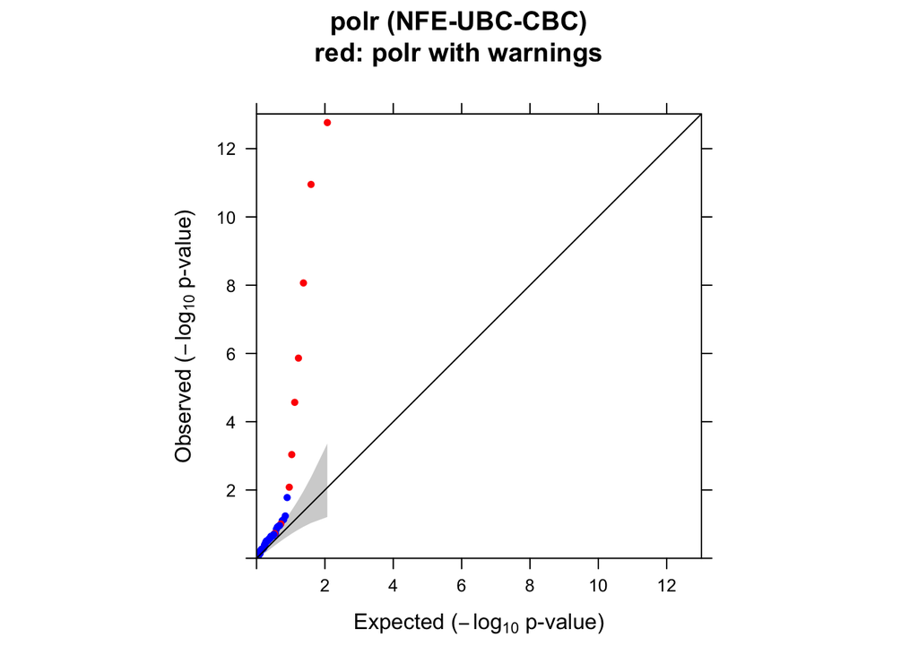

```r
# Make QQ-plot
obs_p <- qq_plot_data.df$polr_p
qqunif.plot(obs_p, should.thin=F,
            main="polr (NFE-UBC-CBC)\nred: polr with warnings",
            col=my_col)
```

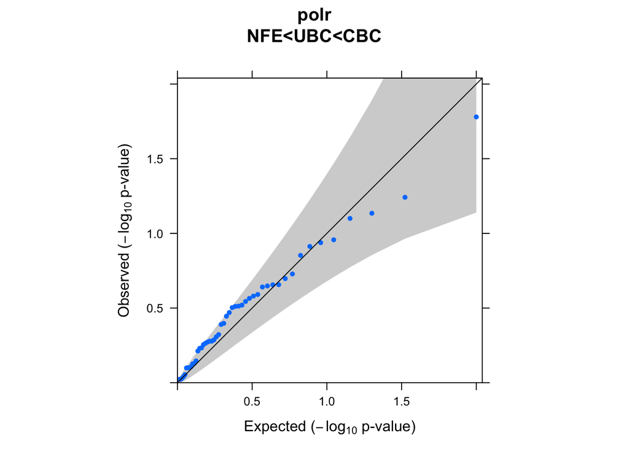

```r
# Exclude genes with polr warnings
qq_plot_data.df <- qq_plot_data.df[qq_plot_data.df$polr_status=="succeeded",]

# Make QQ-plot for the genes with succeeded polr only
obs_p <- qq_plot_data.df$polr_p
qqunif.plot(obs_p, should.thin=F, main="polr\nNFE<UBC<CBC")
```

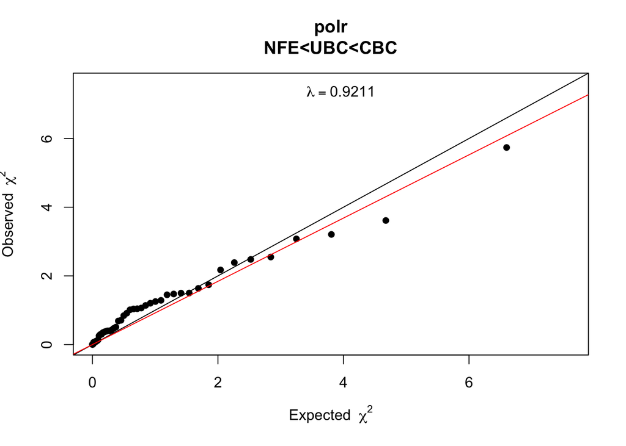

```
## $estimate
## [1] 0.9210802
##
## $se
## [1] 0.02182792
```

```r
exp_p <- ppoints(obs_p)
estlambda2(p.o=obs_p, p.e=exp_p, plot=T, main="polr\nNFE<UBC<CBC")
```

```r
# Clean-up
rm(qq_plot_data.df, my_col, qqunif.plot, obs_p, exp_p)
```

# data_summary

```r
ls()
```

```
## [1] "base_folder"         "genes_data.mx"       "genes_info.df"       "genotypes_imp_wt.mx" "genotypes.mx"        "phenotypes.df"       "variants.df"
```

```r
dim(genotypes.mx)
```

```
## [1] 162 664
```

```r
dim(genotypes_imp_wt.mx)
```

```
## [1] 162 664
```

```r
dim(genes_data.mx)
```

```
## [1]  62 664
```

```r
dim(genes_info.df)
```

```
## [1] 62 29
```

```r
dim(variants.df)
```

```
## [1] 162  88
```

```r
dim(phenotypes.df)
```

```
## [1] 664  31
```

```r
# Check consistency of rownames and colnames
sum(colnames(genotypes.mx) != rownames(phenotypes.df))
```

```
## [1] 0
```

```r
sum(colnames(genes_data.mx) != rownames(phenotypes.df))
```

```
## [1] 0
```

```r
sum(rownames(genes_info.df) != rownames(genes_data.mx))
```

```
## [1] 0
```

```r
sum(rownames(genotypes.mx) != rownames(genotypes_imp_wt.mx))
```

```
## [1] 0
```

```r
sum(rownames(genotypes.mx) != rownames(variants.df))
```

```
## [1] 0
```

# save_data

```r
# Save polr results in text file
write.table(genes_info.df, file=paste(base_folder, "s02_mass_polr.txt", sep="/"), quote=FALSE, sep="\t")

# Save image
save.image(paste(base_folder, "s02_mass_polr.RData", sep="/"))
```

# final_section

```r
ls()
```

```
## [1] "base_folder"         "genes_data.mx"       "genes_info.df"       "genotypes_imp_wt.mx" "genotypes.mx"        "phenotypes.df"       "variants.df"
```

```r
Sys.time()
```

```
## [1] "2019-09-20 15:30:14 BST"
```